# US Immigrant Visas Issued Project

## Project Assets

original information from the US Department of State: https://travel.state.gov/content/travel/en/legal/visa-law0/visa-statistics/annual-reports.html

relevant data: *Table III: Immigrant Visas Issued (by Foreign State of Chargeability or Place of Birth): Fiscal Year YYYY*

[Excel Files 2000 - 2023](https://github.com/Dr-Eberle-Zentrum/Data-projects-with-R-and-GitHub/tree/main/Projects/mauriceschmetzer/Data/Excel)

## Data Wrangling Goal

I would like to be able to extract the data from the PDF files themselves without having to first import the data into Excel via Power Query. Take a look at the function `pdf_text()` from the package `pdftools`. If you cannot make it happen, then use the Excel files. However, the priority is to be able to get the data from the pdf files!

[output not shown]

[output cut: 25 more lines]

```

##    Country Immediate Relatives Special Immigrants Family Preference
## 1  Algeria                  67                  1                10
## 2   Angola                  15                  0                27
## 3    Benin                   7                  0                 5
## 4 Botswana                   4                  0                 0
## 5  Burundi                   2                  0                 0
## 6 Cameroon                 120                  0                12
##   Employment Preference Diversity Immigrants total Continent Fiscal_Year
## 1                    12                  469   559    Africa        2000
## 2                     1                    1    44    Africa        2000
## 3                     1                   22    35    Africa        2000
## 4                     0                    5     9    Africa        2000
## 5                     0                    0     2    Africa        2000
## 6                    14                  321   467    Africa        2000
```

## Tidy Data Format Goal

Below, you will find two pictures of the data (I used the country Algeria and the fiscal year 2000 as an example. However, this applies to every country and every fiscal year). The first picture shows the original data provided by the Department of State. As you can see, the data is in PDF format and is not tidy! I colored the relevant information that I would like to extract in different colors:

- Fiscal_Year = Yellow
- Country = Green
- Continent = Red
- Visa_Type = Blue
- Issued = Pink

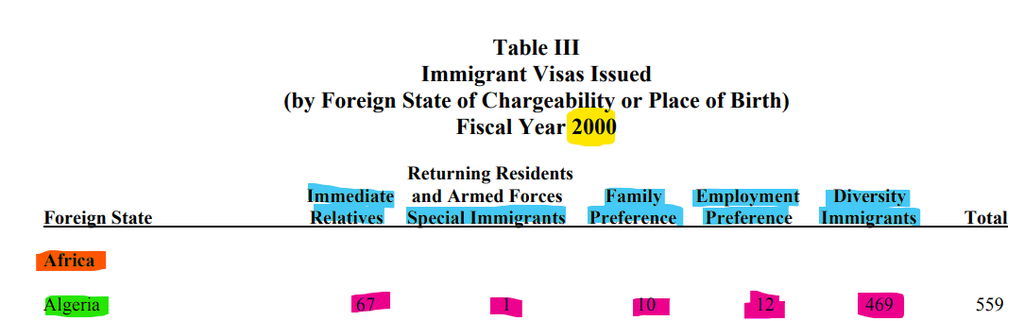

Goal Tidy Data Format

The following picture shows how the final table should look like. Again, I used the same colors to highlight how the data should be shown in tidy format (The color of the values in both screenshots is pink but comes across as if they have different colors so don’t be confused).

There should only be one single table in long format that has all the information of every year for each country.

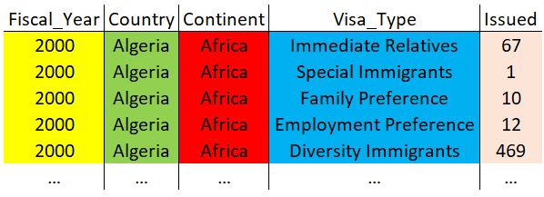

```
# add column Fiscal_Year in code chunk before for future structure with function to extract from more than one file
# fileData$Fiscal_Year <- str_extract(str_extract(pdfText[1], pattern = ".*Fiscal Year \\d{4}"), "\\d{4}")

# pivot to long table
# TODO exclude column "total" cause not necessary
data <- pivot_longer(fileData,
                     cols = c("Immediate Relatives", "Special Immigrants", "Family Preference", "Employment Preference", "Diversity Immigrants"),
                     names_to = "Visa_Type", values_to = "Issued")
head(data)

## # A tibble: 6 × 6
##   Country total Continent Fiscal_Year Visa_Type             Issued
##   <chr>   <chr> <chr>     <chr>       <chr>                 <chr>
## 1 Algeria 559   Africa    2000        Immediate Relatives   67
## 2 Algeria 559   Africa    2000        Special Immigrants    1
## 3 Algeria 559   Africa    2000        Family Preference     10
## 4 Algeria 559   Africa    2000        Employment Preference 12
## 5 Algeria 559   Africa    2000        Diversity Immigrants  469
## 6 Angola  44    Africa    2000        Immediate Relatives   15
```

## Goal Data Visualization

Once the data is tidy, I would like to be able to visualize how many visas were issued by country & visa category over time. For that purpose, I would like to somehow define a specific country that I am interested in (Maybe in a dashboard or simply a variable that I can change) and generate a graph. This could look something like this:

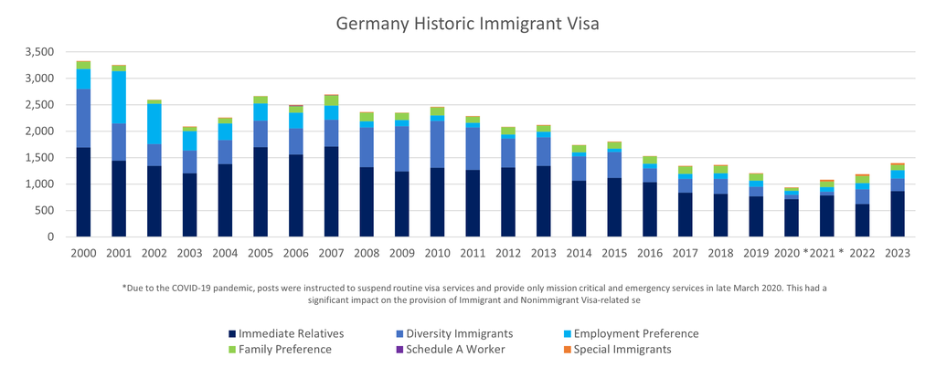

Please create the above graph for the following countries:

- Germany
- China
- Mexico
- India

**TODO** * **Diagrams are not calculating right on y-axis** * **Currently only one year shown**

```
data[data$Country == "Germany",] |>
ggplot( aes(x = Fiscal_Year, y = Issued, fill = Visa_Type)) +
  geom_bar(position = "stack", stat = "identity") +
  scale_color_viridis_d(option="viridis", aesthetics = "fill",
                        labels= c("Immediate Relatives", "Special Immigrants", "Family Preference", "Employment Preference", "Diversity Immigrants")) +
  ggtitle("Germanic Historic Immigrant Visa") +
  theme_linedraw() +
  labs(fill = "") +
  ylab("") +
  xlab("")
```

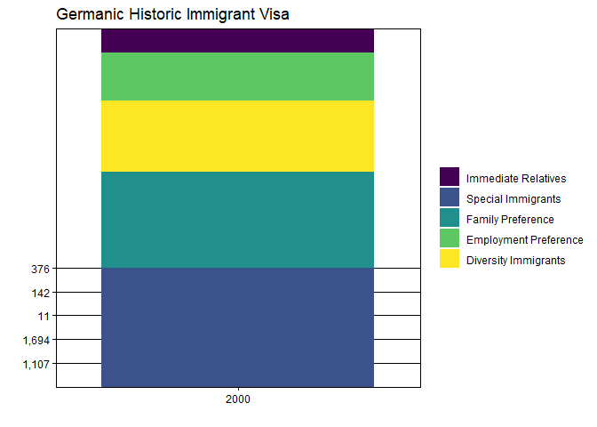

```
data[data$Country == "China",] |>
ggplot( aes(x = Fiscal_Year, y = Issued, fill = Visa_Type)) +
  geom_bar(position = "stack", stat = "identity") +
  scale_color_viridis_d(option="viridis", aesthetics = "fill",
                        labels= c("Immediate Relatives", "Special Immigrants", "Family Preference", "Employment Preference", "Diversity Immigrants")) +
  ggtitle("Chinese Historic Immigrant Visa") +
  theme_linedraw() +
  labs(fill = "") +
  ylab("") +
  xlab("")
```

[figure not shown]

```
data[data$Country == "Mexico",] |>
ggplot( aes(x = Fiscal_Year, y = Issued, fill = Visa_Type)) +
  geom_bar(position = "stack", stat = "identity") +
  scale_color_viridis_d(option="viridis", aesthetics = "fill",
                        labels= c("Immediate Relatives", "Special Immigrants", "Family Preference", "Employment Preference", "Diversity Immigrants")) +
  ggtitle("Mexican Historic Immigrant Visa") +
  theme_linedraw() +
  labs(fill = "") +
  ylab("") +
  xlab("")
```

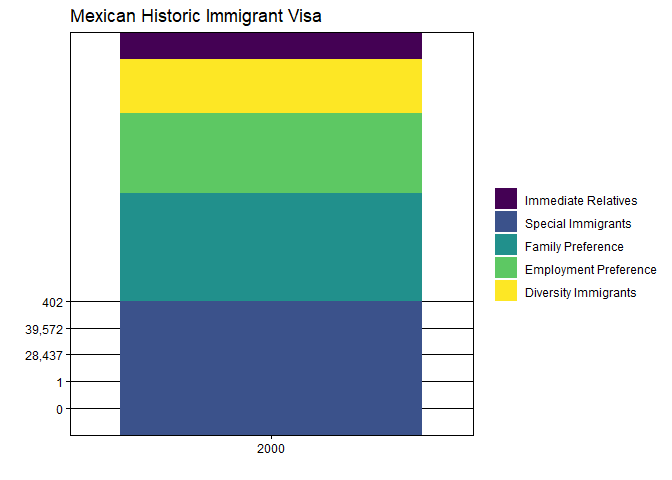

```
data[data$Country == "India",] |>
ggplot( aes(x = Fiscal_Year, y = Issued, fill = Visa_Type)) +
  geom_bar(position = "stack", stat = "identity") +
  scale_color_viridis_d(option="viridis", aesthetics = "fill",
                        labels= c("Immediate Relatives", "Special Immigrants", "Family Preference", "Employment Preference", "Diversity Immigrants")) +
  ggtitle("Indian Historic Immigrant Visa") +
  theme_linedraw() +
  labs(fill = "") +
  ylab("") +
  xlab("")
```

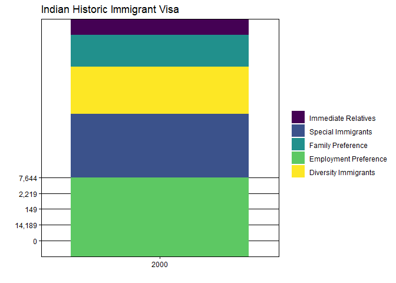